# Reproducible Research 1

Yuchen Han

## loading and processing the data

```r
activity<-read.csv("activity.csv")
```

## What is mean total number of steps taken per day?

first, we need to calculate the total number of steps taken per day:

```r
stepsTotal<-aggregate(steps~date,activity,sum)
```

then we can produce a histogram based on the above results;

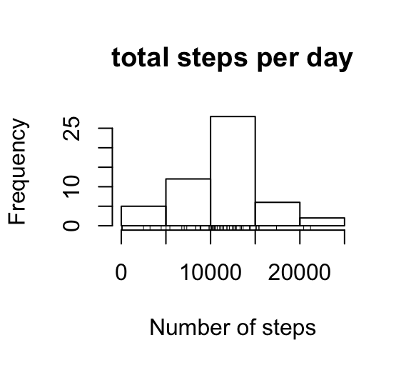

```r
hist(stepsTotal$steps,xlab="Number of steps",main="total steps per day")
rug(stepsTotal$steps)
```

```r
dev.copy(png,file="total steps per day.png")
```

```r
dev.off()
```

calculate the mean and median of the total number of steps taken per day:

```r
stepsAvg<-mean(stepsTotal$steps,na.rm=TRUE);stepsAvg
```

```
## [1] 10766.19
```

```r
stepsMedian<-median(stepsTotal$steps,na.rm=TRUE);stepsMedian
```

```
## [1] 10765
```

## what is the average daily activity pattern?

make a time series plot of the 5-miniute interval(x-axis) and the average number of steps taken,averaged across all days(y-axis).

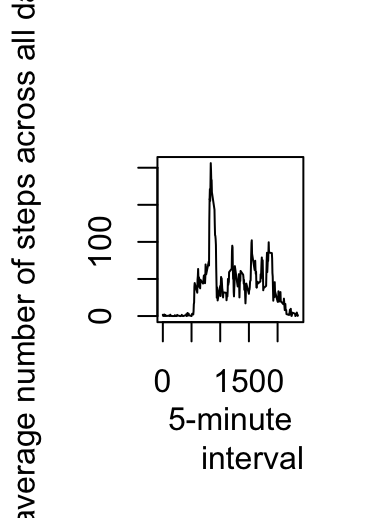

```r
stepsInterval<-aggregate(steps~interval,activity,mean)
plot(stepsInterval$interval,stepsInterval$steps,type="l",xlab="5-minute
     interval",ylab="average number of steps across all days")
```

```r
stepsInterval[which.max(stepsInterval$steps),]
```

```
##     interval    steps
## 104      835 206.1698
```

```r
dev.copy(png,file="average daily activity pattern.png")
```

```r
dev.off()
```

## Imputing missing values

calculate and report the total number of days/intervals where there are missing values in the data set.

```r
naVals<-sum(is.na(activity$steps));naVals
```

```
## [1] 2304
```

there are 2304 missing values in the dataset.

Devise a strategy for filling in all of the missing values in the dataset. The strategy does not need to be sophisticated. For example, you could use the mean/median for that day, or the mean for that 5-minute interval, etc.

Create a new dataset that is equal to the original dataset but with the missing data filled in with the average steps taken on each time interval.

since we are choosing to use the mean to impute the missing NAs, the new dataset will be:

```r
activitySplit<-split(activity,activity$interval)
for (i in 1:length(activitySplit)){
        activitySplit[[i]]$steps[is.na(activitySplit[[i]]$steps)]<-
                stepsInterval$steps[i]
}
library(dplyr)
activityImputed<-bind_rows(activitySplit)
```

Make a histogram of the total number of steps taken each day.

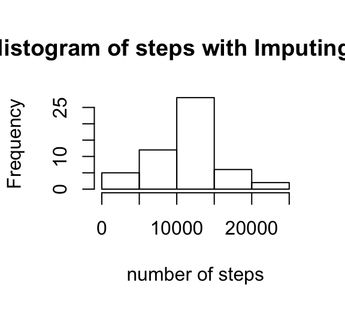

```r
stepsTotalImputed<-aggregate(steps~date,activity,sum)
hist(stepsTotalImputed$steps,xlab="number of steps",main="Histogram of steps with Imputing NAs")
```

```r
dev.copy(png,file="Histograms of steps with Imputing NAs.png")
```

```r
dev.off()
```

then we can calculate and report the mean and median total number of steps taken per day.

```r
stepsImputedAvg<-mean(stepsTotalImputed$steps,na.rm=TRUE);stepsImputedAvg
```

```
## [1] 10766.19
```

```r
stepsImputedMedian<-median(stepsTotalImputed$steps,na.rm=TRUE);stepsImputedMedian
```

```
## [1] 10765
```

## are there differences in activity patterns between weekdays and weekends?

Create a new factor variable in the dataset with two levels – “weekday” and “weekend” indicating whether a given date is a weekday or weekend day.

```r
activityImputed$WeekDay<-ifelse(weekdays(as.Date(activityImputed$date))
=="Saturday"|weekdays(as.Date(activityImputed$date))=="Sunday","weekend","weekday")
```

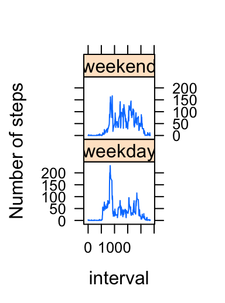

```r
WeekDay.df<-aggregate(steps~WeekDay+interval,activityImputed,mean)
library(lattice)
xyplot(steps~interval|factor(WeekDay),layout=c(1,2),xlab="interval",
       ylab="Number of steps",type="l",data=WeekDay.df)
```

```r
dev.copy(png,file="WeekDay.png")
```

```r
dev.off()
```